# Risk Factor Analysis

## Outcome Variable

**Outcome Variable:** dead6plus

## Predictor Variables

**Intervention Variable:** ever_swasted06

**Adjustment Set:**

- sex
- arm
- brthmon
- vagbrth
- impfloor
- hhwealth_quart
- W_mage
- W_mhtcm
- W_mwtkg
- W_mbmi
- W_meducyrs
- W_feducyrs
- W_nrooms
- W_parity
- impsan
- safeh20
- delta_vagbrth
- delta_impfloor
- delta_hhwealth_quart
- delta_W_mage
- delta_W_mhtcm
- delta_W_mwtkg
- delta_W_mbmi
- delta_W_meducyrs
- delta_W_feducyrs
- delta_W_nrooms
- delta_W_parity
- delta_impsan
- delta_safeh20

## Stratifying Variables

The analysis was stratified on these variable(s):

- studyid
- country

## Data Summary

| studyid | country | ever_swasted06 | dead6plus | n_cell | n |
| --- | --- | --- | --- | --- | --- |
| Burkina Faso Zn | BURKINA FASO | 0 | 0 | 326 | 336 |
| Burkina Faso Zn | BURKINA FASO | 0 | 1 | 2 | 336 |
| Burkina Faso Zn | BURKINA FASO | 1 | 0 | 8 | 336 |
| Burkina Faso Zn | BURKINA FASO | 1 | 1 | 0 | 336 |
| EE | PAKISTAN | 0 | 0 | 332 | 375 |
| EE | PAKISTAN | 0 | 1 | 4 | 375 |
| EE | PAKISTAN | 1 | 0 | 39 | 375 |
| EE | PAKISTAN | 1 | 1 | 0 | 375 |
| GMS-Nepal | NEPAL | 0 | 0 | 516 | 592 |
| GMS-Nepal | NEPAL | 0 | 1 | 2 | 592 |
| GMS-Nepal | NEPAL | 1 | 0 | 74 | 592 |
| GMS-Nepal | NEPAL | 1 | 1 | 0 | 592 |
| iLiNS-DOSE | MALAWI | 0 | 0 | 1643 | 1757 |
| iLiNS-DOSE | MALAWI | 0 | 1 | 112 | 1757 |
| iLiNS-DOSE | MALAWI | 1 | 0 | 1 | 1757 |
| iLiNS-DOSE | MALAWI | 1 | 1 | 1 | 1757 |
| iLiNS-DYAD-M | MALAWI | 0 | 0 | 1103 | 1142 |
| iLiNS-DYAD-M | MALAWI | 0 | 1 | 25 | 1142 |
| iLiNS-DYAD-M | MALAWI | 1 | 0 | 11 | 1142 |
| iLiNS-DYAD-M | MALAWI | 1 | 1 | 3 | 1142 |
| JiVitA-3 | BANGLADESH | 0 | 0 | 19764 | 20985 |
| JiVitA-3 | BANGLADESH | 0 | 1 | 270 | 20985 |
| JiVitA-3 | BANGLADESH | 1 | 0 | 918 | 20985 |
| JiVitA-3 | BANGLADESH | 1 | 1 | 33 | 20985 |
| JiVitA-4 | BANGLADESH | 0 | 0 | 5065 | 5242 |
| JiVitA-4 | BANGLADESH | 0 | 1 | 43 | 5242 |
| JiVitA-4 | BANGLADESH | 1 | 0 | 129 | 5242 |
| JiVitA-4 | BANGLADESH | 1 | 1 | 5 | 5242 |
| Keneba | GAMBIA | 0 | 0 | 2038 | 2312 |
| Keneba | GAMBIA | 0 | 1 | 52 | 2312 |
| Keneba | GAMBIA | 1 | 0 | 206 | 2312 |
| Keneba | GAMBIA | 1 | 1 | 16 | 2312 |
| MAL-ED | BANGLADESH | 0 | 0 | 224 | 240 |
| MAL-ED | BANGLADESH | 0 | 1 | 0 | 240 |
| MAL-ED | BANGLADESH | 1 | 0 | 16 | 240 |
| MAL-ED | BANGLADESH | 1 | 1 | 0 | 240 |
| MAL-ED | INDIA | 0 | 0 | 214 | 235 |
| MAL-ED | INDIA | 0 | 1 | 0 | 235 |
| MAL-ED | INDIA | 1 | 0 | 21 | 235 |
| MAL-ED | INDIA | 1 | 1 | 0 | 235 |
| MAL-ED | PERU | 0 | 0 | 271 | 273 |
| MAL-ED | PERU | 0 | 1 | 1 | 273 |
| MAL-ED | PERU | 1 | 0 | 1 | 273 |
| MAL-ED | PERU | 1 | 1 | 0 | 273 |
| MAL-ED | SOUTH AFRICA | 0 | 0 | 254 | 261 |
| MAL-ED | SOUTH AFRICA | 0 | 1 | 0 | 261 |
| MAL-ED | SOUTH AFRICA | 1 | 0 | 7 | 261 |
| MAL-ED | SOUTH AFRICA | 1 | 1 | 0 | 261 |
| MAL-ED | TANZANIA, UNITED REPUBLIC OF | 0 | 0 | 240 | 245 |
| MAL-ED | TANZANIA, UNITED REPUBLIC OF | 0 | 1 | 0 | 245 |
| MAL-ED | TANZANIA, UNITED REPUBLIC OF | 1 | 0 | 5 | 245 |
| MAL-ED | TANZANIA, UNITED REPUBLIC OF | 1 | 1 | 0 | 245 |
| PROVIDE | BANGLADESH | 0 | 0 | 589 | 617 |
| PROVIDE | BANGLADESH | 0 | 1 | 3 | 617 |
| PROVIDE | BANGLADESH | 1 | 0 | 25 | 617 |
| PROVIDE | BANGLADESH | 1 | 1 | 0 | 617 |
| SAS-CompFeed | INDIA | 0 | 0 | 1283 | 1384 |
| SAS-CompFeed | INDIA | 0 | 1 | 8 | 1384 |
| SAS-CompFeed | INDIA | 1 | 0 | 90 | 1384 |
| SAS-CompFeed | INDIA | 1 | 1 | 3 | 1384 |
| SAS-FoodSuppl | INDIA | 0 | 0 | 372 | 402 |
| SAS-FoodSuppl | INDIA | 0 | 1 | 2 | 402 |
| SAS-FoodSuppl | INDIA | 1 | 0 | 26 | 402 |
| SAS-FoodSuppl | INDIA | 1 | 1 | 2 | 402 |
| TanzaniaChild2 | TANZANIA, UNITED REPUBLIC OF | 0 | 0 | 2021 | 2096 |
| TanzaniaChild2 | TANZANIA, UNITED REPUBLIC OF | 0 | 1 | 0 | 2096 |
| TanzaniaChild2 | TANZANIA, UNITED REPUBLIC OF | 1 | 0 | 75 | 2096 |
| TanzaniaChild2 | TANZANIA, UNITED REPUBLIC OF | 1 | 1 | 0 | 2096 |
| VITAMIN-A | INDIA | 0 | 0 | 3360 | 3606 |
| VITAMIN-A | INDIA | 0 | 1 | 21 | 3606 |
| VITAMIN-A | INDIA | 1 | 0 | 215 | 3606 |
| VITAMIN-A | INDIA | 1 | 1 | 10 | 3606 |
| ZVITAMBO | ZIMBABWE | 0 | 0 | 10444 | 11610 |
| ZVITAMBO | ZIMBABWE | 0 | 1 | 356 | 11610 |
| ZVITAMBO | ZIMBABWE | 1 | 0 | 760 | 11610 |
| ZVITAMBO | ZIMBABWE | 1 | 1 | 50 | 11610 |

The following strata were considered:

- studyid: Burkina Faso Zn, country: BURKINA FASO
- studyid: EE, country: PAKISTAN
- studyid: GMS-Nepal, country: NEPAL
- studyid: iLiNS-DOSE, country: MALAWI
- studyid: iLiNS-DYAD-M, country: MALAWI
- studyid: JiVitA-3, country: BANGLADESH
- studyid: JiVitA-4, country: BANGLADESH
- studyid: Keneba, country: GAMBIA
- studyid: MAL-ED, country: BANGLADESH
- studyid: MAL-ED, country: INDIA
- studyid: MAL-ED, country: PERU
- studyid: MAL-ED, country: SOUTH AFRICA
- studyid: MAL-ED, country: TANZANIA, UNITED REPUBLIC OF
- studyid: PROVIDE, country: BANGLADESH
- studyid: SAS-CompFeed, country: INDIA
- studyid: SAS-FoodSuppl, country: INDIA
- studyid: TanzaniaChild2, country: TANZANIA, UNITED REPUBLIC OF
- studyid: VITAMIN-A, country: INDIA
- studyid: ZVITAMBO, country: ZIMBABWE

### Dropped Strata

Some strata were dropped due to rare outcomes:

- studyid: Burkina Faso Zn, country: BURKINA FASO
- studyid: EE, country: PAKISTAN
- studyid: GMS-Nepal, country: NEPAL
- studyid: iLiNS-DOSE, country: MALAWI
- studyid: iLiNS-DYAD-M, country: MALAWI
- studyid: MAL-ED, country: BANGLADESH
- studyid: MAL-ED, country: INDIA
- studyid: MAL-ED, country: PERU
- studyid: MAL-ED, country: SOUTH AFRICA
- studyid: MAL-ED, country: TANZANIA, UNITED REPUBLIC OF
- studyid: PROVIDE, country: BANGLADESH
- studyid: SAS-CompFeed, country: INDIA
- studyid: SAS-FoodSuppl, country: INDIA
- studyid: TanzaniaChild2, country: TANZANIA, UNITED REPUBLIC OF

## Methods Detail

We’re interested in the causal parameters $E[Y_a]$ for all values of $a \in \mathcal{A}$. These parameters represent the mean outcome if, possibly contrary to fact, we intervened to set all units to have $A=a$. Under the randomization and positivity assumptions, these are identified by the statistical parameters $\psi_a=E_W[E_{Y|A,W}(Y|A=a,W)]$. In addition, we’re interested in the mean of $Y$, $E[Y]$ under no intervention (the observed mean). We will estimate these parameters by using SuperLearner to fit the relevant likelihood factors – $E_{Y|A,W}(Y|A=a,W)$ and $p(A=a|W)$, and then updating our likelihood fit using a joint TMLE.

For unadjusted analyses ($W=\{\}$), initial likelihoods were estimated using Lrnr_glm to estimate the simple $E(Y|A)$ and Lrnr_mean to estimate $p(A)$. For adjusted analyses, a small library containing Lrnr_glmnet, Lrnr_xgboost, and Lrnr_mean was used.

Having estimated these parameters, we will then use the delta method to estimate relative risks and attributable risks relative to a prespecified baseline level of $A$.

# Results Detail

## Results Plots

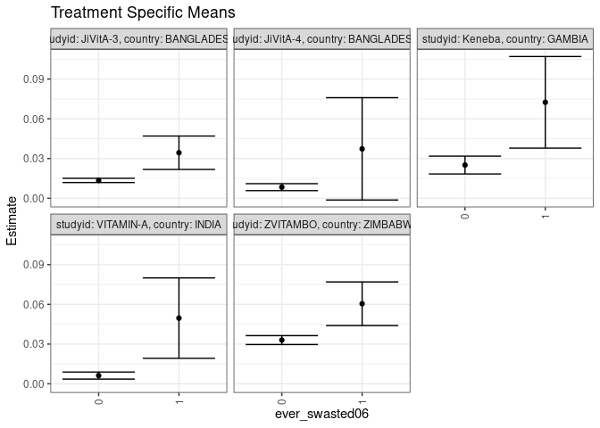

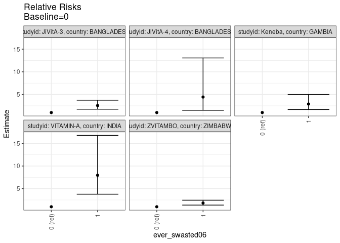

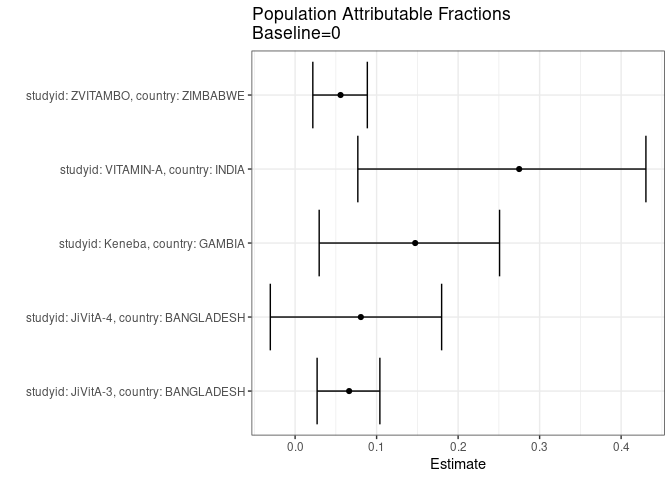

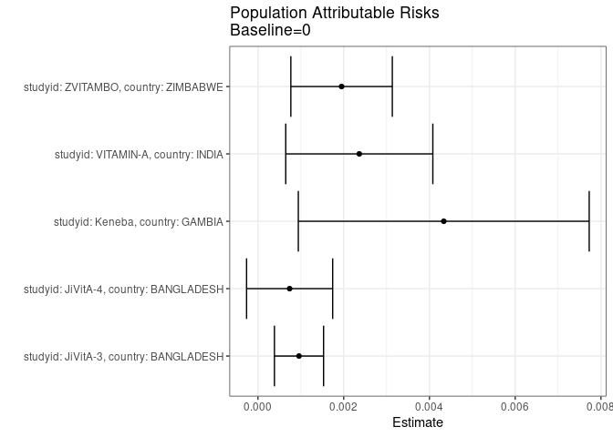

## Results Table

### Parameter: TSM

| studyid | country | intervention_level | baseline_level | estimate | ci_lower | ci_upper |
| --- | --- | --- | --- | --- | --- | --- |
| JiVitA-3 | BANGLADESH | 0 | NA | 0.0134816 | 0.0118894 | 0.0150738 |
| JiVitA-3 | BANGLADESH | 1 | NA | 0.0343829 | 0.0217699 | 0.0469959 |
| JiVitA-4 | BANGLADESH | 0 | NA | 0.0084182 | 0.0057961 | 0.0110402 |
| JiVitA-4 | BANGLADESH | 1 | NA | 0.0373134 | -0.0013266 | 0.0759535 |
| Keneba | GAMBIA | 0 | NA | 0.0250782 | 0.0183438 | 0.0318125 |
| Keneba | GAMBIA | 1 | NA | 0.0724653 | 0.0378862 | 0.1070445 |
| VITAMIN-A | INDIA | 0 | NA | 0.0062334 | 0.0035770 | 0.0088899 |
| VITAMIN-A | INDIA | 1 | NA | 0.0495965 | 0.0192500 | 0.0799430 |
| ZVITAMBO | ZIMBABWE | 0 | NA | 0.0330196 | 0.0296523 | 0.0363868 |
| ZVITAMBO | ZIMBABWE | 1 | NA | 0.0604348 | 0.0439637 | 0.0769058 |

### Parameter: E(Y)

| studyid | country | intervention_level | baseline_level | estimate | ci_lower | ci_upper |
| --- | --- | --- | --- | --- | --- | --- |
| JiVitA-3 | BANGLADESH | NA | NA | 0.0144389 | 0.0128023 | 0.0160755 |
| JiVitA-4 | BANGLADESH | NA | NA | 0.0091568 | 0.0064104 | 0.0119032 |
| Keneba | GAMBIA | NA | NA | 0.0294118 | 0.0225232 | 0.0363003 |
| VITAMIN-A | INDIA | NA | NA | 0.0085968 | 0.0055832 | 0.0116104 |
| ZVITAMBO | ZIMBABWE | NA | NA | 0.0349699 | 0.0316281 | 0.0383116 |

### Parameter: RR

| studyid | country | intervention_level | baseline_level | estimate | ci_lower | ci_upper |
| --- | --- | --- | --- | --- | --- | --- |
| JiVitA-3 | BANGLADESH | 0 | 0 | 1.000000 | 1.000000 | 1.000000 |
| JiVitA-3 | BANGLADESH | 1 | 0 | 2.550359 | 1.742697 | 3.732339 |
| JiVitA-4 | BANGLADESH | 0 | 0 | 1.000000 | 1.000000 | 1.000000 |
| JiVitA-4 | BANGLADESH | 1 | 0 | 4.432489 | 1.503686 | 13.065864 |
| Keneba | GAMBIA | 0 | 0 | 1.000000 | 1.000000 | 1.000000 |
| Keneba | GAMBIA | 1 | 0 | 2.889579 | 1.671402 | 4.995606 |
| VITAMIN-A | INDIA | 0 | 0 | 1.000000 | 1.000000 | 1.000000 |
| VITAMIN-A | INDIA | 1 | 0 | 7.956524 | 3.775453 | 16.767861 |
| ZVITAMBO | ZIMBABWE | 0 | 0 | 1.000000 | 1.000000 | 1.000000 |
| ZVITAMBO | ZIMBABWE | 1 | 0 | 1.830272 | 1.368381 | 2.448071 |

### Parameter: PAR

| studyid | country | intervention_level | baseline_level | estimate | ci_lower | ci_upper |
| --- | --- | --- | --- | --- | --- | --- |
| JiVitA-3 | BANGLADESH | 0 | NA | 0.0009573 | 0.0003842 | 0.0015303 |
| JiVitA-4 | BANGLADESH | 0 | NA | 0.0007386 | -0.0002654 | 0.0017427 |
| Keneba | GAMBIA | 0 | NA | 0.0043336 | 0.0009413 | 0.0077259 |
| VITAMIN-A | INDIA | 0 | NA | 0.0023633 | 0.0006478 | 0.0040789 |
| ZVITAMBO | ZIMBABWE | 0 | NA | 0.0019503 | 0.0007669 | 0.0031337 |

### Parameter: PAF

| studyid | country | intervention_level | baseline_level | estimate | ci_lower | ci_upper |
| --- | --- | --- | --- | --- | --- | --- |
| JiVitA-3 | BANGLADESH | 0 | NA | 0.0662998 | 0.0270033 | 0.1040092 |
| JiVitA-4 | BANGLADESH | 0 | NA | 0.0806659 | -0.0304130 | 0.1797706 |
| Keneba | GAMBIA | 0 | NA | 0.1473425 | 0.0295397 | 0.2508455 |
| VITAMIN-A | INDIA | 0 | NA | 0.2749104 | 0.0769629 | 0.4304077 |
| ZVITAMBO | ZIMBABWE | 0 | NA | 0.0557707 | 0.0217424 | 0.0886154 |